# Module 2 — Expression Analysis and Candidate Biomarker Discovery

BBCC2026 Tutorial: From 19,938 Genes to Tumor-vs-Normal DEGs with limma

Francesco Cecere** · *Senior Bioinformatic Researcher* · AORN Santobono-Pausilipon IRCCS

Eva Luna Tarallo** · *Junior Bioinformatic Researcher* · AORN Santobono-Pausilipon IRCCS

18 ottobre 2026

# From Module 1

Module 1 confirmed that TPM sums, PCA structure, and sample-sample correlations are reasonable enough to proceed, while flagging that histology is not the only source of variation in the data (PC1 typically explains well under half of total variance in this dataset — see Module 1). With QC complete, this module goes end-to-end: from expression values to lists of **differentially expressed genes (DEGs)** between each tumor subtype and normal kidney, with an explicit stop along the way to reconnect to the metadata work from Module 0.

**Session plan (≈60 minutes):** presenting the dataset (5 min) → explicit bridge to Module 0 (5 min) → preparing the dataset (10 min) → differential expression with limma (15 min) → volcano plots, PCA and heatmaps (15 min) → shared DEGs with an UpSet plot (5 min) → closing pediatric lens (5 min).

# Part 1 — Presenting the Dataset

Every module so far has used the same real dataset: **TARGET-WT**, RNA-seq expression (TPM) for 124 real pediatric Wilms tumor patients from the Children’s Oncology Group’s NWTS-5 trial, released through the NCI’s **TARGET** program via the **GDC Data Portal**. Samples split into two groups by real clinical histology (`Favorable`, 82 samples, and `Unfavorable`/anaplastic, 42 samples — see Module 0) — not a proxy label, the same grouping used in real clinical risk stratification for this cancer.

**A note on pediatric-specific resources.** The NCI’s **TARGET** program (via the **GDC Data Portal**) is the pediatric-cancer counterpart to the adult-focused **TCGA** — the two share the same portal and file formats, but TARGET covers cancers TCGA does not, including Wilms tumor. This tutorial uses TARGET-WT directly, with the expression matrix and clinical sheet already assembled into `data/` so no live GDC download is needed during the workshop itself (see the README if you want to see how it was built).

# Part 2 — Explicit Bridge to Module 0

Module 0 built and debugged, by hand, a clinical metadata schema with fields like `patient_id`, `age_years`, `sex`, `diagnosis`, and `consent_status`, then joined the real TARGET-WT expression matrix to a real clinical sheet. Let’s look at what metadata actually ships with this real dataset, side by side with that schema.

```r
# Reload the tumor expression matrix (TPM) and the verified sample metadata from Module 0.
tumor_tpm_raw <- read_csv(
  "data/TARGET_WT_gene_expression_tpm.csv",
  show_col_types = FALSE
) %>%
  rename(gene_symbol = gene_name)

sample_metadata <- read_csv("data/sample_metadata.csv", show_col_types = FALSE)
```

| case_submitter_id | histologic_subtype | age_at_diagnosis_days | sex_at_birth | vital_status | race | ethnicity | age_years |
| --- | --- | --- | --- | --- | --- | --- | --- |
| TARGET-50-PAKGMU | Unfavorable | 1121 | female | Alive | white | not reported | 3.1 |
| TARGET-50-PAKRCC | Unfavorable | 1466 | male | Alive | white | not hispanic or latino | 4 |
| TARGET-50-PAJNNC | Favorable | 281 | male | Alive | not reported | not reported | 0.8 |
| TARGET-50-PAJNLT | Favorable | 1546 | female | Dead | black or african american | not hispanic or latino | 4.2 |
| TARGET-50-PAKJGM | Favorable | 1007 | male | Dead | white | not hispanic or latino | 2.8 |
| TARGET-50-PAJLNJ | Favorable | 325 | female | Dead | white | not reported | 0.9 |
| TARGET-50-PAKGED | Unfavorable | 2809 | female | Alive | white | not hispanic or latino | 7.7 |
| TARGET-50-PAJMFU | Unfavorable | 1348 | female | Alive | not reported | hispanic or latino | 3.7 |
| TARGET-50-PAJLPX | Unfavorable | 2702 | male | Alive | black or african american | not hispanic or latino | 7.4 |
| TARGET-50-CAAAAC | Favorable | 2244 | female | Dead | white | not hispanic or latino | 6.1 |

[output cut: 114 more lines]

Same conceptual fields: TARGET-WT is far closer to the Module 0 schema than a typical public expression dataset.

| field | present_in_module0_exercise | present_in_target_wt |
| --- | --- | --- |
| sample/patient ID | Yes (patient_id) | Yes (case_submitter_id) |
| group/diagnosis | Yes (diagnosis, free text) | Yes (histologic_subtype: Favorable/Unfavorable) |
| age | Yes (age_years) | Yes (age_at_diagnosis_days) |
| sex | Yes (sex) | Yes (sex_at_birth) |
| collection date | Yes (collection_date) | No |
| consent status | Yes (consent_status) | No |

**The bridge, stated plainly.** `case_submitter_id` and `histologic_subtype` are literally the same *kind* of information as the `patient_id` and `diagnosis` fields built and debugged by hand in Module 0 — and here, age and sex carry over too, because TARGET is a dedicated, consent-governed pediatric consortium rather than a dataset assembled for a single narrow purpose. It still does **not** ship collection date or a machine-readable consent field via this API — real metadata is rarely complete even from a well-run program, which is exactly why every join is verified rather than trusted, as Module 0 just did.

# Part 3 — Differential Expression: Each Tumor Subtype vs. Normal Kidney

The rest of this module asks one question, gene by gene: **“is this gene expressed differently in the tumor than in normal kidney?”** We ask it twice, once for each histology subtype:

- **Favorable vs. Control**: 82 favorable-histology tumors against 6 normal kidney samples.
- **Unfavorable vs. Control**: 42 unfavorable (anaplastic) tumors against the same 6 normal samples.

The workflow is: prepare the dataset → fit a statistical model → visualize the results (volcano plots, heatmaps) → compare the two lists of differentially expressed genes (DEGs).

## Step 1 — Preparing the Dataset

TARGET-WT also includes a small number of genuinely matched **normal kidney** samples (“Solid Tissue Normal”) from the same consortium. These are our **control** group.

```r
# Real matched-normal RNA-seq samples, assembled the same way as the tumor
# matrix (see data-prep/build_target_wt_data.R).
control_tpm_raw <- read_csv(
  "data/TARGET_WT_control_gene_expression_tpm.csv",
  show_col_types = FALSE
) %>%
  rename(gene_symbol = gene_name)

control_clinical <- read_csv("data/TARGET_WT_control_clinical_raw.csv", show_col_types = FALSE)
```

**Only 6 real normal samples exist for this entire project** (TARGET-WT has 652 registered cases in total, but only 6 open-access, matched-normal RNA-seq files), and all 6 come from **Favorable**-histology patients. Both comparisons therefore use **the same shared pool of 6 normals** as reference: a real but small control group.

```r
# All 6 normal-tissue donors ALSO appear among the Favorable tumor samples:
# same patient, two different biological samples (tumor + matched normal).
# case_submitter_id alone can't distinguish them, so the normal samples are
# tracked by their own sample_submitter_id (e.g. "...-11A").
datatable(
  control_clinical %>%
    mutate(also_has_tumor_sample = case_submitter_id %in% sample_metadata$case_submitter_id),
  rownames = FALSE, options = list(dom = "t", ordering = FALSE),
  caption = "The 6 normal-tissue samples, and whether the same patient also has a tumor sample."
)
```

| sample_submitter_id | case_submitter_id | sample_type | also_has_tumor_sample |
| --- | --- | --- | --- |
| TARGET-50-PALKCW-11A | TARGET-50-PALKCW | Solid Tissue Normal | True |
| TARGET-50-PAJNSL-11A | TARGET-50-PAJNSL | Solid Tissue Normal | True |
| TARGET-50-CAAAAQ-11A | TARGET-50-CAAAAQ | Solid Tissue Normal | True |
| TARGET-50-PAJPHA-11A | TARGET-50-PAJPHA | Solid Tissue Normal | True |
| TARGET-50-PAJNRL-11A | TARGET-50-PAJNRL | Solid Tissue Normal | True |
| TARGET-50-CAAAAR-11A | TARGET-50-CAAAAR | Solid Tissue Normal | True |

Next we put tumors and controls into **one expression matrix** (genes × samples) and build a matching **sample sheet** that says which group each column belongs to. The order of the columns in the matrix and the order of the rows in the sample sheet must be identical: the model reads the group of column *i* from row *i* of the sample sheet.

```r
# Same 19,938 genes, in the same order, in both files.
stopifnot(identical(tumor_tpm_raw$gene_symbol, control_tpm_raw$gene_symbol))

tpm_matrix <- as.matrix(bind_cols(tumor_tpm_raw[, -1], control_tpm_raw[, -1]))
rownames(tpm_matrix) <- tumor_tpm_raw$gene_symbol

# One row per column of tpm_matrix, in the same order.
de_samples <- tibble(sample_id = colnames(tpm_matrix)) %>%
  left_join(sample_metadata %>% select(sample_id = case_submitter_id, histologic_subtype), by = "sample_id") %>%
  mutate(group = factor(replace_na(histologic_subtype, "Control"),
                        levels = c("Control", "Favorable", "Unfavorable"))) %>%
  select(sample_id, group)

stopifnot(identical(de_samples$sample_id, colnames(tpm_matrix)))

n_control     <- sum(de_samples$group == "Control")
n_favorable   <- sum(de_samples$group == "Favorable")
n_unfavorable <- sum(de_samples$group == "Unfavorable")
```

| group | samples |
| --- | --- |
| Control | 6 |
| Favorable | 82 |
| Unfavorable | 42 |

### Filtering low-expressed genes

Genes that are barely expressed carry almost no information but still count as tests, which makes the multiple-testing correction harsher for every other gene. We keep a gene only if it reaches **TPM ≥ 1 in at least 6 samples**, the size of the smallest group: that way a gene expressed only in the controls (or only in a small group of tumors) is still kept.

```r
keep_genes <- rowSums(tpm_matrix >= 1) >= n_control

# log2(TPM + 1): the scale used for every test and plot below.
log2_expr <- log2(tpm_matrix[keep_genes, ] + 1)
```

| step | genes |
| --- | --- |
| Genes before filtering | 19938 |
| Genes kept (TPM &gt;= 1 in at least 6 samples) | 15995 |
| Genes removed | 3943 |

## Step 2 — Differential Expression with limma

We use **limma**, one of the most widely used packages for differential expression. It fits, for every gene, a linear model of its log2 expression as a function of the sample group, then tests the differences we ask for.

**Why limma, and not DESeq2?** DESeq2 and edgeR model **raw read counts**: their statistics depend on the counting noise of reads, which is not recoverable from TPM. Our data are TPM, which are already normalized for sequencing depth and gene length. For values like these the standard choice is **limma on log2(TPM + 1)** with the `trend = TRUE` option (“limma-trend”), which accounts for the fact that low-expressed genes are noisier than highly expressed ones.

**Why it helps with only 6 controls.** limma’s *empirical Bayes* step (`eBayes`) borrows information across all genes: each gene’s variance is pulled toward the typical variance of genes with similar expression. With small groups, a single gene’s variance estimate is very unstable; this “shrinkage” makes the test much more reliable, which is exactly what a small pediatric control group needs.

The model is set up in three steps:

1. **Design matrix**: one column per group (Control, Favorable, Unfavorable), so the model estimates the mean log2 expression of each group for every gene.
2. **Contrasts**: the differences we want to test, `Favorable − Control` and `Unfavorable − Control`. Both are estimated from **one model fitted on all 130 samples**, so the 6 controls are used once and the variance estimate uses every sample.
3. **eBayes**: computes moderated t-statistics and p-values; `topTable()` then adds the Benjamini-Hochberg adjusted p-value (`p_adj`), which corrects for testing thousands of genes at once.

```r
design <- model.matrix(~ 0 + group, data = de_samples)
colnames(design) <- levels(de_samples$group)

contrast_matrix <- makeContrasts(
  Favorable_vs_Control   = Favorable - Control,
  Unfavorable_vs_Control = Unfavorable - Control,
  levels = design
)

fit <- lmFit(log2_expr, design)
fit <- contrasts.fit(fit, contrast_matrix)
fit <- eBayes(fit, trend = TRUE, robust = TRUE)
```

| sample_id | Control | Favorable | Unfavorable |
| --- | --- | --- | --- |
| TARGET-50-PAKGMU | 0 | 0 | 1 |
| TARGET-50-PAKRCC | 0 | 0 | 1 |
| TARGET-50-PAJNNC | 0 | 1 | 0 |
| TARGET-50-PAJPHA-11A | 1 | 0 | 0 |
| TARGET-50-PAJNRL-11A | 1 | 0 | 0 |
| TARGET-50-CAAAAR-11A | 1 | 0 | 0 |

### Calling DEGs

A gene is called a **DEG** when it is both statistically significant and changed by a meaningful amount:

- **`p_adj < 0.05`**: less than 5% of the genes we call are expected to be false positives;
- **`|log2FC| > 1`**: expression at least **doubled** (log2FC > 1, *up* in the tumor) or **halved** (log2FC < −1, *down* in the tumor) compared with normal kidney.

```r
padj_cutoff  <- 0.05
log2fc_cutoff <- 1

get_de_table <- function(contrast_name) {
  topTable(fit, coef = contrast_name, number = Inf, sort.by = "P") %>%
    as_tibble(rownames = "gene_symbol") %>%
    transmute(
      gene_symbol,
      log2FC         = logFC,
      mean_log2_expr = AveExpr,
      t,
      p.value        = P.Value,
      p_adj          = adj.P.Val,
      status = case_when(
        p_adj < padj_cutoff & log2FC >  log2fc_cutoff ~ "Up",
        p_adj < padj_cutoff & log2FC < -log2fc_cutoff ~ "Down",
        TRUE                                          ~ "Not DEG"
      )
    )
}

de_favorable_vs_control   <- get_de_table("Favorable_vs_Control")
de_unfavorable_vs_control <- get_de_table("Unfavorable_vs_Control")

de_both <- bind_rows(
  "Favorable vs Control"   = de_favorable_vs_control,
  "Unfavorable vs Control" = de_unfavorable_vs_control,
  .id = "comparison"
)
```

| comparison | Up | Down | DEGs | Not DEG |
| --- | --- | --- | --- | --- |
| Favorable vs Control | 5179 | 1578 | 6757 | 9238 |
| Unfavorable vs Control | 4927 | 1659 | 6586 | 9409 |

**Thousands of DEGs: expected, not a red flag.** Tumor-vs-*normal* comparisons routinely change thousands of genes, because tumor tissue differs from normal tissue in many basic ways at once (proliferation, immune infiltrate, blood supply, cell types). What matters is whether the top genes make biological sense, which we check below.

**A caveat to keep in mind.** The 6 controls come from patients who also contribute a Favorable tumor sample, but the model treats every sample as an independent individual. With 6 of 88 samples involved the effect is small, but a fully rigorous analysis would model the patient (e.g. with limma’s `duplicateCorrelation()`).

The complete DEG lists are below (top 200 per comparison, ranked by adjusted p-value; the full tables with every tested gene are exported to `results/`).

| gene_symbol | log2FC | mean_log2_expr | t | p.value | p_adj | status |
| --- | --- | --- | --- | --- | --- | --- |
| UMOD | -12.4 | 0.625 | -90.5 | 2.07e-120 | 3.299999999999999e-116 | Down |
| SLC9A4 | -4.29 | 0.234 | -45.7 | 1.1e-82 | 8.809999999999998e-79 | Down |
| KNG1 | -7.36 | 0.437 | -45.1 | 6.959999999999998e-82 | 3.71e-78 | Down |
| SFTA2 | -3.66 | 0.294 | -41.8 | 6.669999999999999e-78 | 2.669999999999999e-74 | Down |
| VGLL1 | -5.11 | 0.34 | -40.2 | 9.979999999999998e-76 | 3.189999999999999e-72 | Down |
| FOXI1 | -5.62 | 0.387 | -39.7 | 3.9e-75 | 1.04e-71 | Down |
| AQP2 | -9.13 | 0.578 | -35.8 | 9.829999999999999e-70 | 2.25e-66 | Down |
| CLCNKA | -6.96 | 0.65 | -35.3 | 5.469999999999999e-69 | 1.09e-65 | Down |
| CWH43 | -3.27 | 0.22 | -35 | 1.43e-68 | 2.54e-65 | Down |
| GP2 | -4.19 | 0.216 | -34.6 | 5.639999999999998e-68 | 9.029999999999998e-65 | Down |

[output cut: 190 more lines]

| gene_symbol | log2FC | mean_log2_expr | t | p.value | p_adj | status |
| --- | --- | --- | --- | --- | --- | --- |
| UMOD | -12.4 | 0.625 | -87.8 | 9.859999999999997e-119 | 1.58e-114 | Down |
| SLC9A4 | -4.29 | 0.234 | -44.3 | 6.559999999999999e-81 | 5.249999999999999e-77 | Down |
| KNG1 | -7.38 | 0.437 | -43.8 | 2.27e-80 | 1.21e-76 | Down |
| SFTA2 | -3.62 | 0.294 | -40.1 | 1.2e-75 | 4.779999999999999e-72 | Down |
| FOXI1 | -5.73 | 0.387 | -39.2 | 1.61e-74 | 5.139999999999999e-71 | Down |
| VGLL1 | -5.1 | 0.34 | -38.8 | 5.809999999999999e-74 | 1.55e-70 | Down |
| AQP2 | -9.08 | 0.578 | -34.6 | 7.259999999999999e-68 | 1.66e-64 | Down |
| CWH43 | -3.3 | 0.22 | -34.3 | 1.78e-67 | 3.56e-64 | Down |
| GDF3 | -3.97 | 0.408 | -34.2 | 2.19e-67 | 3.9e-64 | Down |
| CLCNKA | -6.93 | 0.65 | -34.1 | 3.73e-67 | 5.969999999999999e-64 | Down |

[output cut: 190 more lines]

```r
# Full result tables (every tested gene), ranked by p-value; Module 3 reads them.
dir.create("results", showWarnings = FALSE)
write_csv(de_favorable_vs_control, "results/differential_expression_favorable_vs_control.csv")
write_csv(de_unfavorable_vs_control, "results/differential_expression_unfavorable_vs_control.csv")
```

### A quick biological sanity check

Before trusting thousands of DEGs, look at a few genes whose behavior in Wilms tumor is known in advance:

- **`SIX1`, `SIX2`, `EYA1`, `CITED1`**: transcription factors of the *embryonic* nephron progenitor program. Wilms tumor arises from retained embryonic kidney tissue, so they should be strongly **up** in the tumor.
- **`UMOD`, `AQP2`, `SLC22A2`**: markers of *mature*, functioning kidney tubules. A tumor made of undifferentiated cells should have lost them: strongly **down**.

| comparison | gene_symbol | log2FC | p_adj | status |
| --- | --- | --- | --- | --- |
| Favorable vs Control | SIX1 | 5.98 | 3.36e-30 | Up |
| Unfavorable vs Control | SIX1 | 5.83 | 3.41e-28 | Up |
| Favorable vs Control | SIX2 | 9.5 | 4.26e-31 | Up |
| Unfavorable vs Control | SIX2 | 9.37 | 1.8e-29 | Up |
| Favorable vs Control | EYA1 | 6.77 | 2.74e-31 | Up |
| Unfavorable vs Control | EYA1 | 6.65 | 1.72e-29 | Up |
| Favorable vs Control | CITED1 | 2.8 | 1.56e-08 | Up |
| Unfavorable vs Control | CITED1 | 2.8 | 4.28e-08 | Up |
| Favorable vs Control | UMOD | -12.41 | 3.299999999999999e-116 | Down |
| Unfavorable vs Control | UMOD | -12.43 | 1.58e-114 | Down |

[output cut: 4 more lines]

If these genes move in the expected direction, the pipeline is measuring real biology rather than noise.

## Step 3 — Volcano Plots

A volcano plot shows every tested gene at once: **effect size** on the x-axis (log2 fold-change, tumor vs normal) and **significance** on the y-axis (−log10 of the adjusted p-value, so smaller p-values are higher up). DEGs sit in the two upper corners: red for genes **up** in the tumor, blue for genes **down**. The 10 most significant genes of each comparison are labeled.

```r
volcano_labels <- de_both %>%
  filter(status != "Not DEG") %>%
  group_by(comparison) %>%
  slice_min(p_adj, n = 10, with_ties = FALSE) %>%
  ungroup()
```

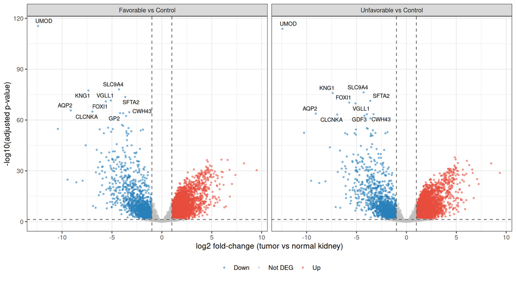

**How to read it.** The two volcanos look very similar: most of the difference from normal kidney is shared by both histologies. Notice also that the most significant genes (the highest points) are mostly on the **left**: the strongest signal is the *loss* of mature kidney genes in the tumor.

## Step 4 — PCA on the DEGs

In Module 1 the PCA used *all* expressed genes, and the histology groups did not separate clearly. Here we repeat the PCA using **only the DEGs** of each comparison, on **all 130 samples** (controls, Favorable and Unfavorable together). If the DEGs capture a real tumor-vs-normal difference, the 6 controls should sit far away from the tumors along PC1.

```r
group_colors <- c(Control = "#7f8c8d", Favorable = "#2980b9", Unfavorable = "#e74c3c")

run_deg_pca <- function(de_table, comparison_label) {
  deg_genes <- de_table %>% filter(status != "Not DEG") %>% pull(gene_symbol)

  # Same settings as Module 1: genes centered, not scaled (all on the log2 scale).
  pca <- prcomp(t(log2_expr[deg_genes, ]), center = TRUE, scale. = FALSE)
  variance_pct <- round(100 * pca$sdev^2 / sum(pca$sdev^2), 1)

  as_tibble(pca$x[, 1:2], rownames = "sample_id") %>%
    left_join(de_samples, by = "sample_id") %>%
    mutate(comparison = paste0(comparison_label, " DEGs (n = ", length(deg_genes), ")\n",
                               "PC1 ", variance_pct[1], "%, PC2 ", variance_pct[2], "%"))
}

pca_degs <- bind_rows(
  run_deg_pca(de_favorable_vs_control,   "Favorable vs Control"),
  run_deg_pca(de_unfavorable_vs_control, "Unfavorable vs Control")
)
```

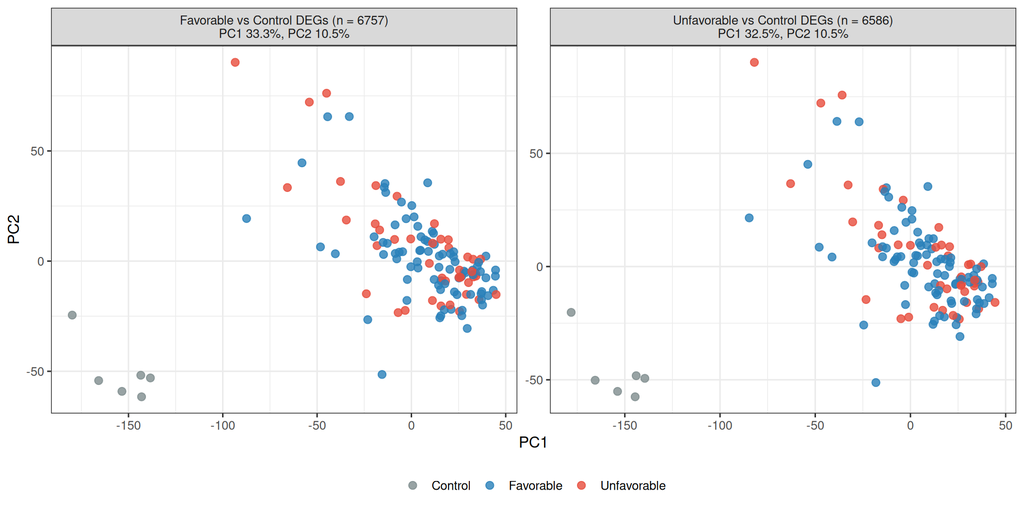

**How to read it.** PC1 should separate the gray controls from the tumors: that is the tumor-vs-normal signal the DEGs were selected for. Notice that Favorable and Unfavorable tumors still overlap: the DEGs describe what *both* subtypes have in common against normal kidney, not what distinguishes them from each other. Keep in mind that this PCA is partly circular: the genes were *chosen* because they separate tumors from controls, so a clean separation here confirms the selection worked; it is not independent evidence.

## Step 5 — Heatmaps of the Top DEGs

A volcano plot gives one number per gene; a heatmap shows the sample-by-sample pattern behind it. For each comparison we take the **top 25 up and top 25 down DEGs** (by adjusted p-value) and plot their expression in **all 130 samples**: the 6 controls and both tumor subtypes.

- Each gene (row) is **z-scored** (`scale = "row"`): its values are expressed as standard deviations from that gene’s own mean, so genes with very different expression levels share one color scale. Red = higher than the gene’s average, blue = lower.
- Both genes and samples are **clustered**: similar rows and similar columns are placed next to each other (the trees on the side and top).
- The color bar on top shows each sample’s group. If the DEGs are real, the controls should cluster together, away from the tumors. Showing both subtypes also lets you see whether the DEGs of one comparison behave the same way in the other subtype.

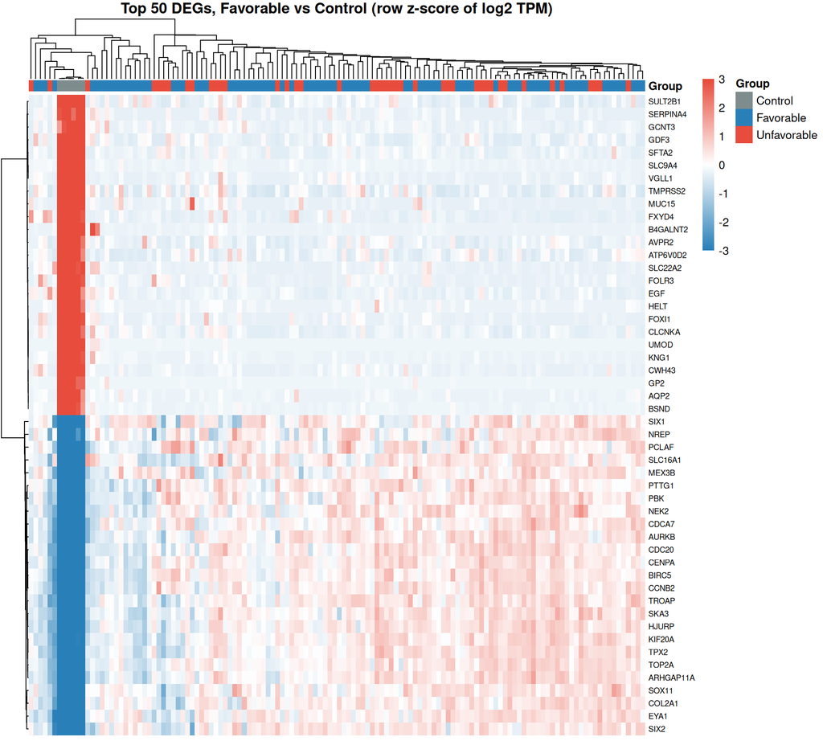

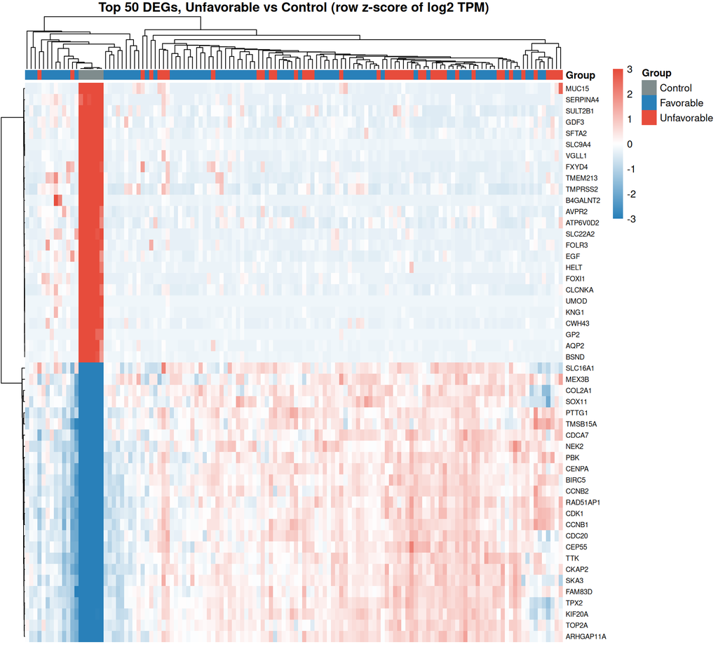

```r
plot_top_deg_heatmap <- function(de_table, title) {
  top_genes <- de_table %>%
    filter(status != "Not DEG") %>%
    group_by(status) %>%
    slice_min(p_adj, n = 25, with_ties = FALSE) %>%
    pull(gene_symbol)

  annotation <- data.frame(Group = de_samples$group, row.names = de_samples$sample_id)

  pheatmap(
    log2_expr[top_genes, ],
    scale = "row",
    color = colorRampPalette(c("#2980b9", "white", "#e74c3c"))(100),
    breaks = seq(-3, 3, length.out = 101),
    clustering_distance_rows = "correlation", clustering_distance_cols = "correlation",
    clustering_method = "average",
    annotation_col = annotation,
    annotation_colors = list(Group = group_colors),
    show_colnames = FALSE, fontsize_row = 7, border_color = NA, treeheight_row = 20,
    main = title
  )
}
```

**What to look for.** Two clear blocks: genes up in the tumor (red across tumors, blue in controls) and genes down (the opposite), with the 6 controls clustering together. A gene whose color is patchy across tumors (red in some, blue in others) is driven by a subset of patients rather than the whole group, which is worth knowing before calling it a biomarker.

## Step 6 — Which DEGs Are Shared? An UpSet Plot

The two volcanos looked alike, but how many DEGs exactly are shared, and how many are specific to one histology? With more than two sets a Venn diagram becomes hard to read, so we use an **UpSet plot**. We compare four sets: genes **up** and **down** in each comparison.

How to read it:

- **Left bars**: the size of each set (e.g. all genes up in Favorable vs Control).
- **Dots below the main plot**: a combination of sets. A single dot = genes found *only* in that set; dots joined by a line = genes found in *all* the joined sets (and no others).
- **Top bars**: how many genes fall in that exact combination.

```r
deg_sets <- list(
  `Favorable up`     = de_favorable_vs_control   %>% filter(status == "Up")   %>% pull(gene_symbol),
  `Favorable down`   = de_favorable_vs_control   %>% filter(status == "Down") %>% pull(gene_symbol),
  `Unfavorable up`   = de_unfavorable_vs_control %>% filter(status == "Up")   %>% pull(gene_symbol),
  `Unfavorable down` = de_unfavorable_vs_control %>% filter(status == "Down") %>% pull(gene_symbol)
)
```

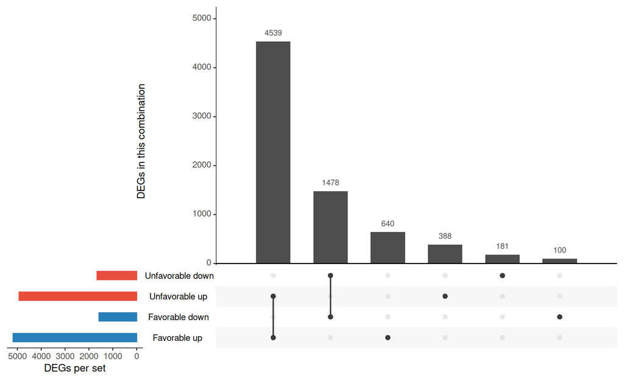

The table below lists every DEG with its category, so any bar of the UpSet plot can be looked up gene by gene. Use the search box (e.g. type `Unfavorable only`) to filter.

| gene_symbol | log2FC_favorable | status_favorable | log2FC_unfavorable | status_unfavorable | category |
| --- | --- | --- | --- | --- | --- |
| OGN | 2.42 | Up | 2.23 | Not DEG | Favorable only |
| IGF2BP1 | 2.72 | Up | 2.18 | Not DEG | Favorable only |
| MMP9 | 2.73 | Up | 1.9 | Not DEG | Favorable only |
| TFAP2A | -1.97 | Down | -1.77 | Not DEG | Favorable only |
| BST2 | 1.75 | Up | 1.58 | Not DEG | Favorable only |
| NDNF | 2.8 | Up | 1.52 | Not DEG | Favorable only |
| SLFN13 | 1.77 | Up | 1.52 | Not DEG | Favorable only |
| NLRP2 | -1.75 | Down | -1.51 | Not DEG | Favorable only |
| CLDN3 | -1.56 | Down | -1.48 | Not DEG | Favorable only |
| HOXD12 | 1.57 | Up | 1.34 | Not DEG | Favorable only |

[output cut: 7316 more lines]

| category | genes |
| --- | --- |
| Favorable only | 740 |
| Shared down | 1478 |
| Shared up | 4539 |
| Unfavorable only | 569 |

**Interpretation.** The largest bars are the **shared** sets: most of what separates a Wilms tumor from normal kidney is the same in both histologies (loss of mature kidney genes, gain of the embryonic program). The smaller histology-specific sets are where subtype differences may hide. Keep in mind that “Unfavorable only” can also mean “just missed the cutoff in Favorable”: a gene at p_adj = 0.04 in one comparison and 0.06 in the other is not truly specific. This is why the log2FC of *both* comparisons is shown in the table above.

**What carries forward to Module 3.** The two vs-control result tables exported above are the starting point for Module 3: genes that distinguish a subtype from normal kidney are the candidate panel for asking “how is regulation wired differently in this subtype”.

# Part 4 — Closing Pediatric Lens

This entire analysis ran on **124 samples** (82 favorable, 42 unfavorable) — and that number, by real-world pediatric-oncology standards, is actually a relatively large, hard-won cohort: it exists only because the NCI’s **TARGET** program and the Children’s Oncology Group coordinated a multi-institution trial (NWTS-5) specifically to assemble enough anaplastic (unfavorable-histology) cases to study at all, since that subtype is individually rare.

- **A p-value is not a biomarker.** Effect size (`log2FC`) and biological plausibility matter as much as, or more than, the adjusted p-value alone. The expected behavior of known Wilms tumor genes (`SIX1`/`SIX2`/`EYA1` up, mature-kidney genes down) is a reassuring sign, but not sufficient on its own.
- **The control group is the weakest link.** Every DEG in this module is measured against only 6 normal samples, all from Favorable-histology patients. limma’s empirical Bayes shrinkage makes the most of them, but a bigger, independent control set would change the exact gene lists.
- **Pediatric rare disease and cancer studies are almost always underpowered by adult-oncology standards.** With 42 unfavorable-histology samples here, and adult cancer cohort studies routinely running into the hundreds or thousands, every statistical test in this module runs on a fraction of the data an equivalent adult study would have — which argues for prioritizing genes with **large, consistent effect sizes** over borderline p-values (which is why our DEG definition requires |log2FC| > 1 on top of p_adj < 0.05), and for treating any single-cohort candidate list as hypothesis-generating rather than diagnostic.
- **Any candidate list needs independent validation** — an orthogonal cohort, an orthogonal assay (e.g. qPCR, IHC), or both — before it can be called a biomarker in the clinical sense. Statistical significance in an expression comparison is also not the same question as mechanism: Module 3 takes the natural next step by asking how the genes distinguishing each subtype from normal kidney *regulate each other differently* between Favorable and Unfavorable, using gene regulatory network inference.

Generated on 18 ottobre 2026 · Francesco Cecere (Senior Bioinformatic Researcher) · Eva Luna Tarallo (Junior Bioinformatic Researcher) · AORN Santobono-Pausilipon IRCCS